# Station Data vs. Daymet: Climate and impact on model output

Katie Renwick

12/23/2016

## Impact on model output

### First: impact on variables compared to flux data

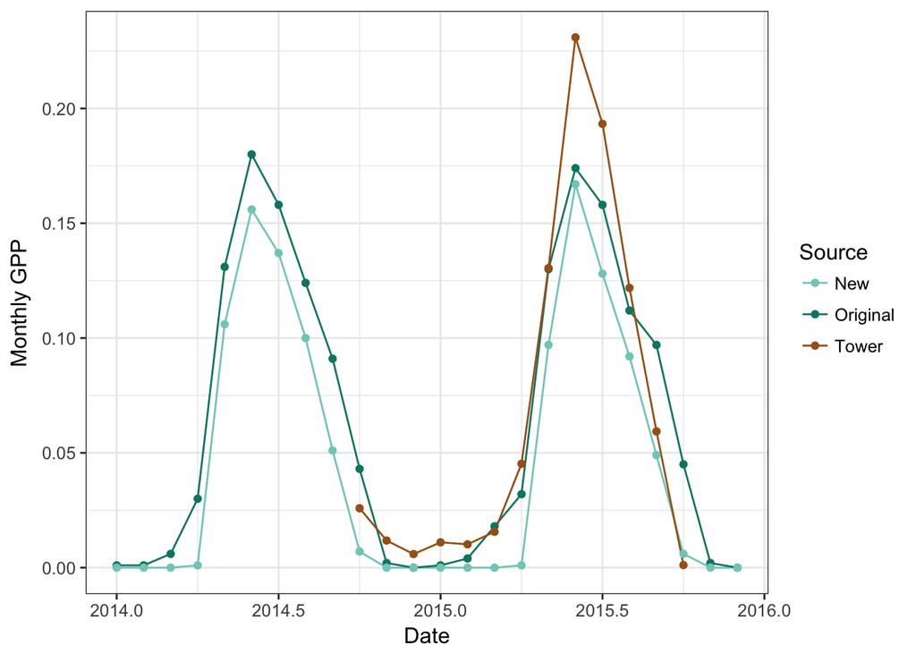

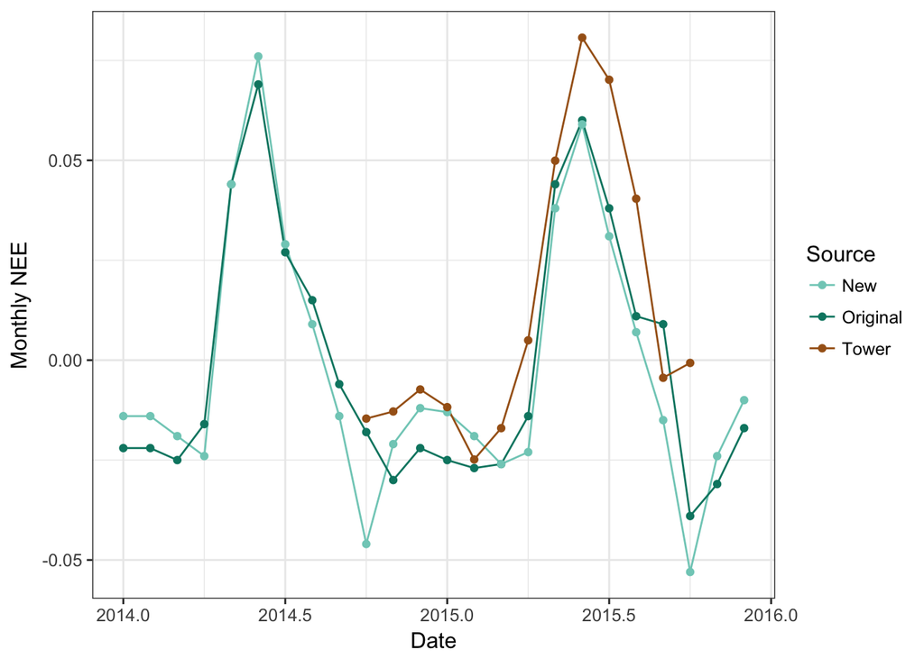

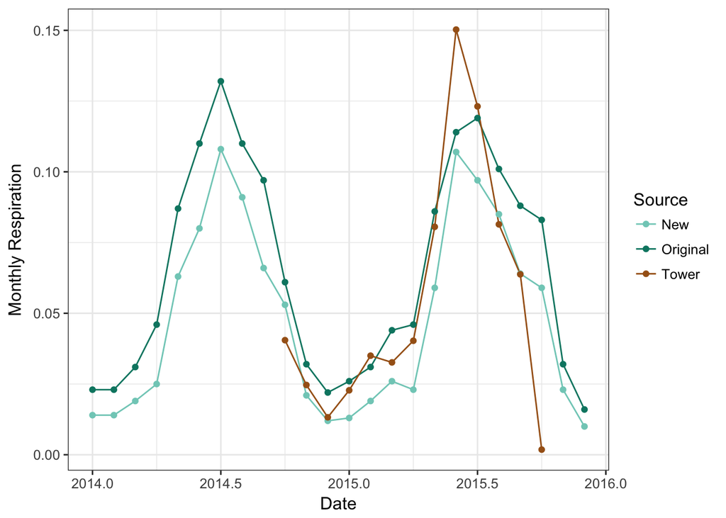

### Second: Plot additional monthly variables

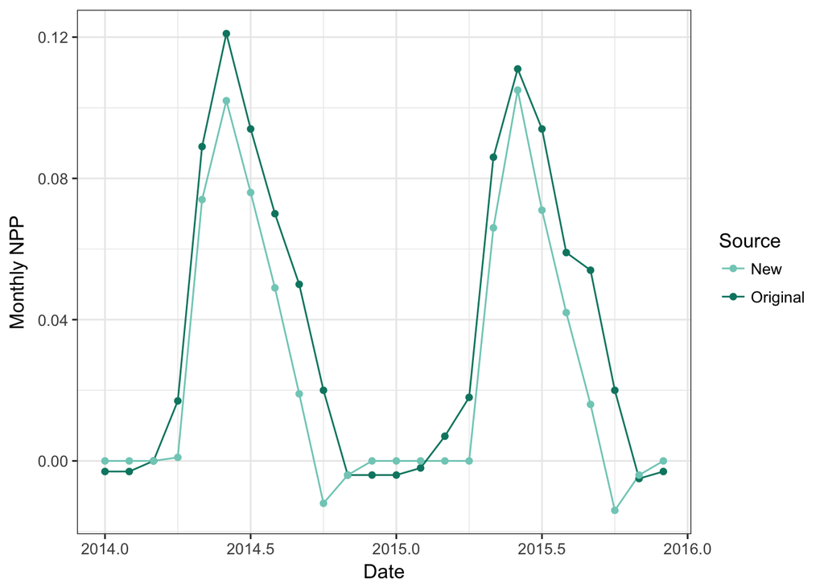

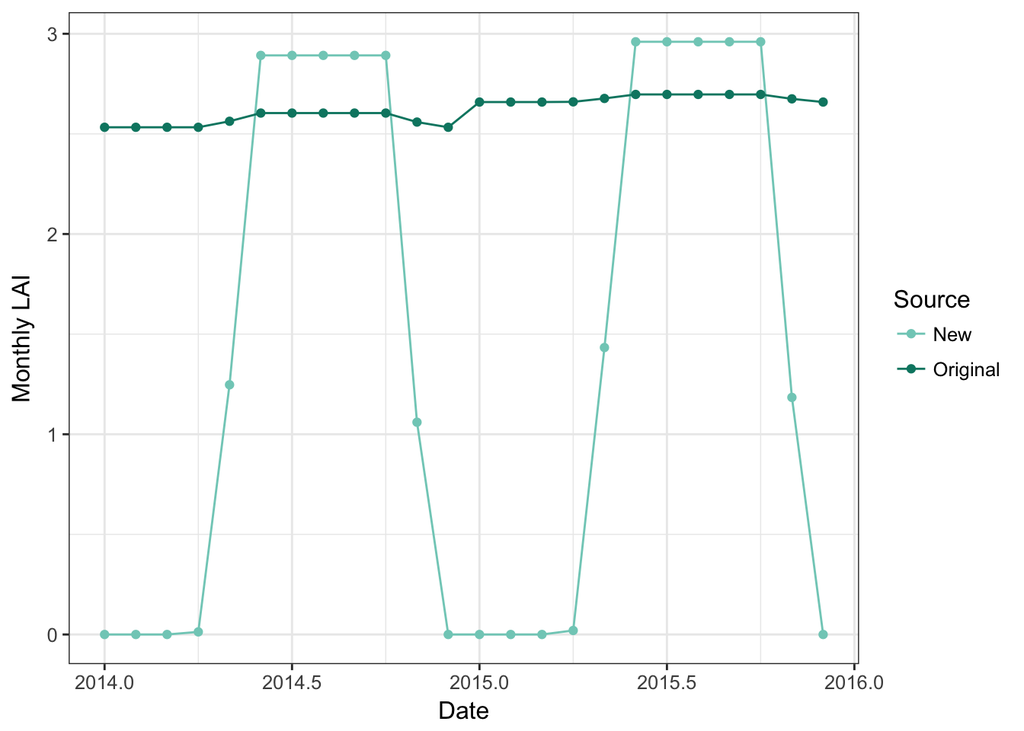

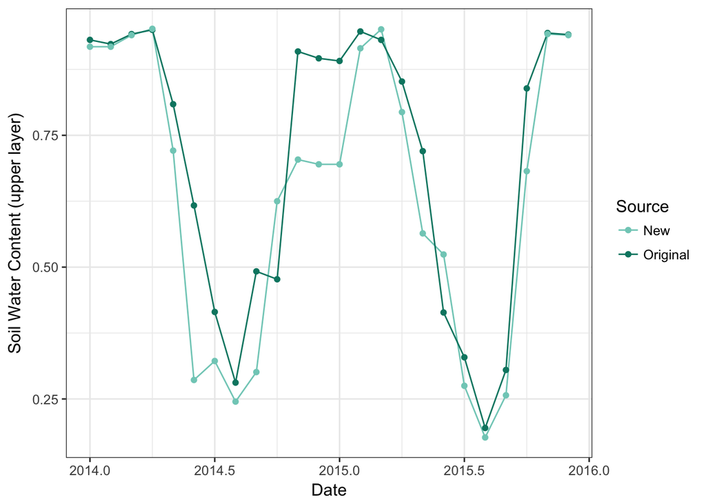

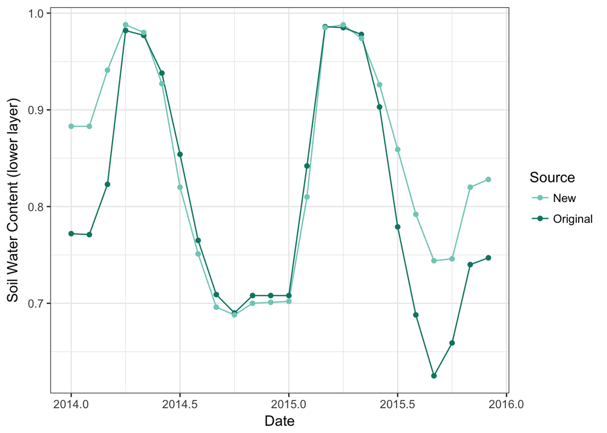

### Third: plot annual variables by PFT

Note that there is only one year of overlap in the driver data: 2014. I’ve highlighted this year with a dashed line.

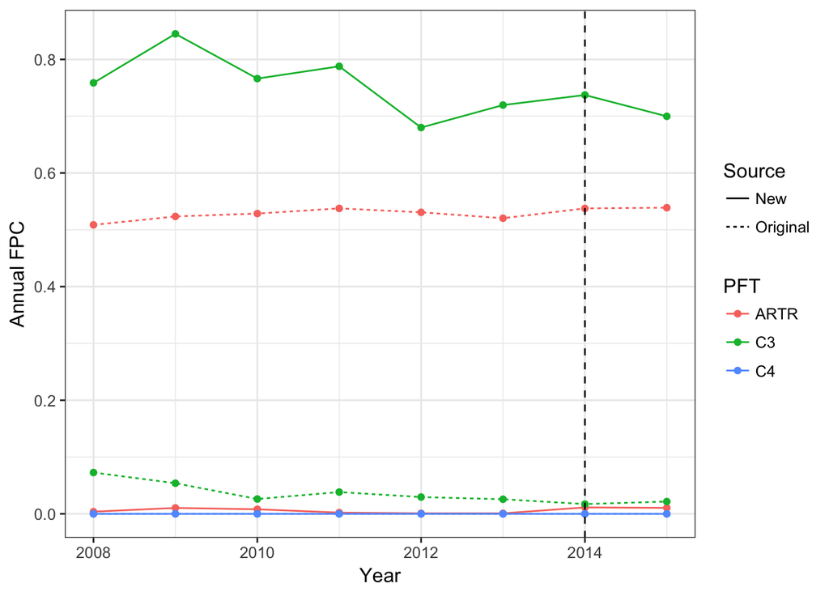

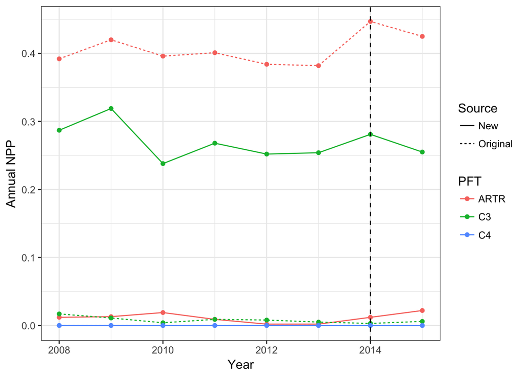

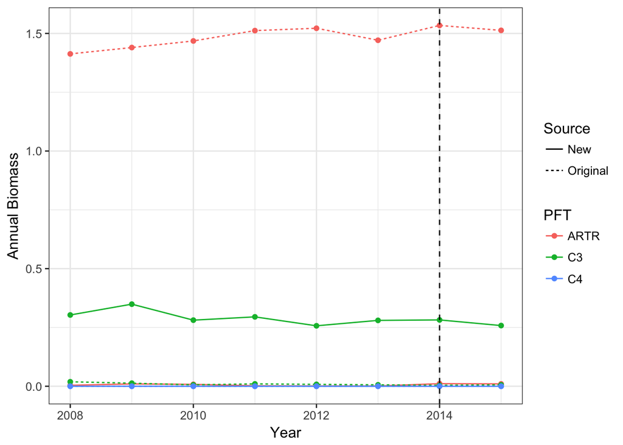

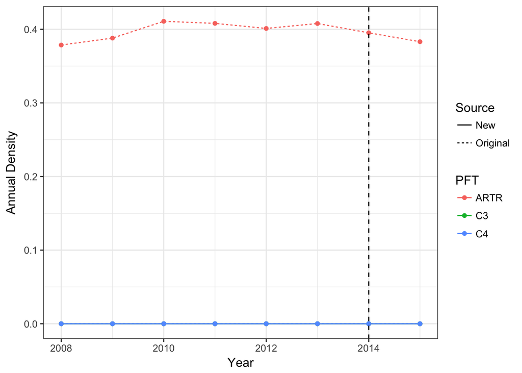

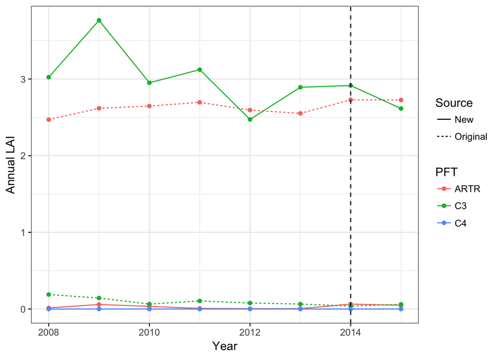

### Fourth: plot annual variables, looking just at total

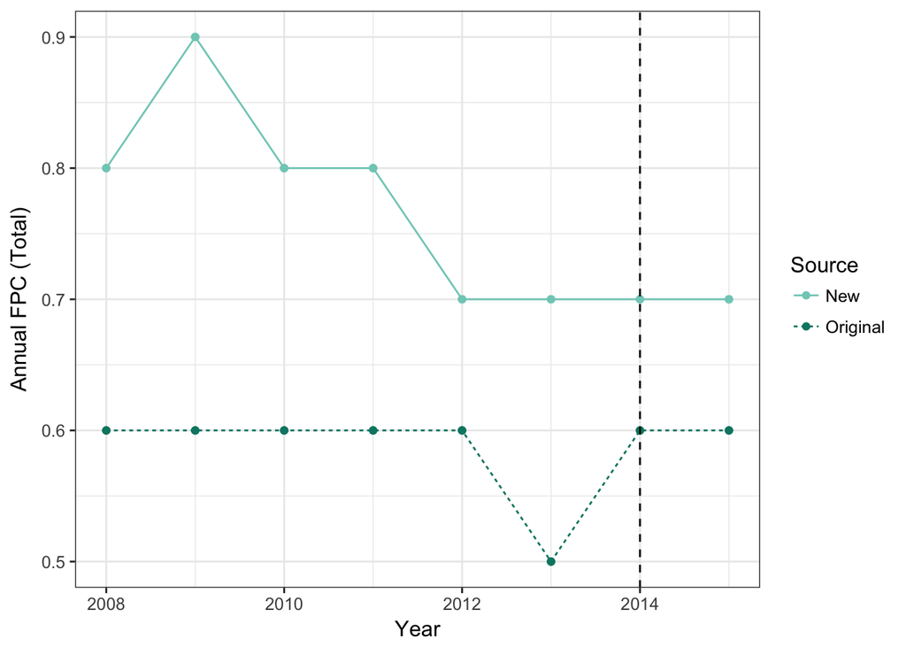

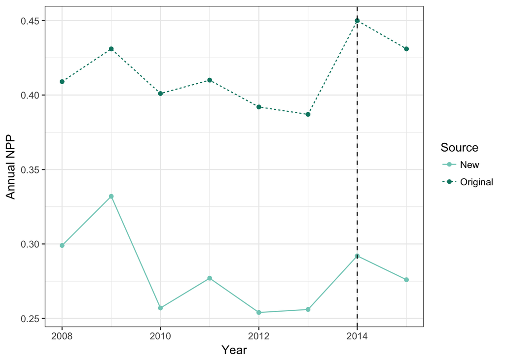

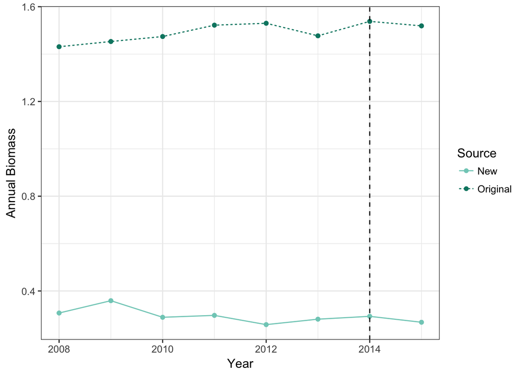

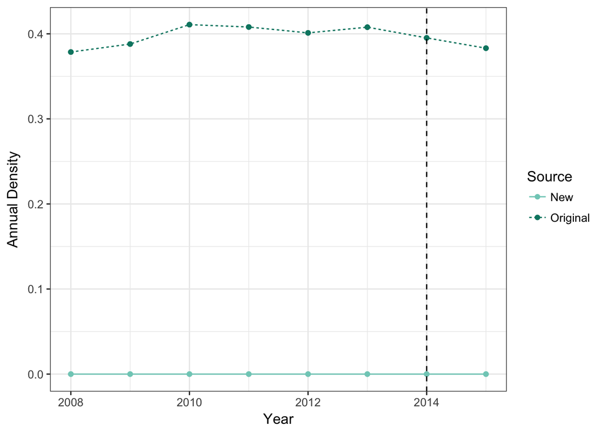

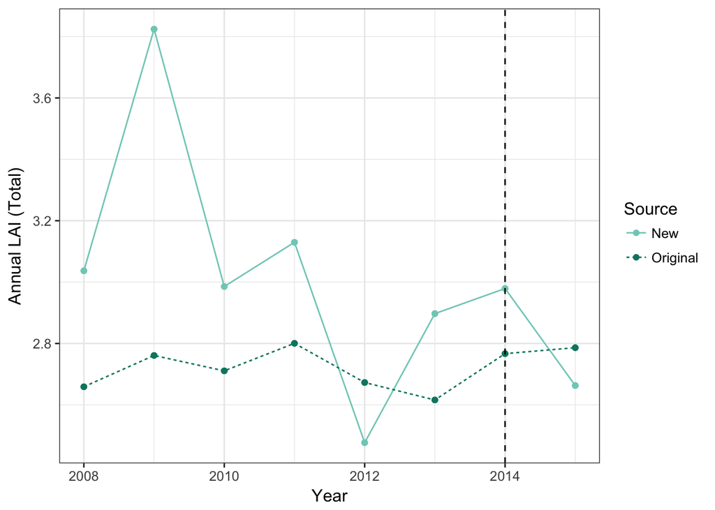

### Just for fun: NPP over modern times.

This shows what a big effect CO2 has throughout the past century. It’s much more obvious with the station data because there is less variation in climate, so the trend in increasing NPP is driven entirely by increasing atmospheric CO2.

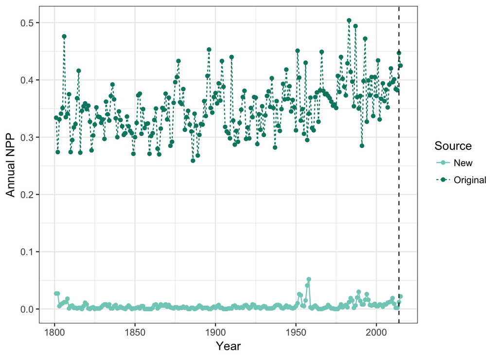

## Run parameters, which were the same (except end year) for both simulations:

- param “annual_output” (num 1)
- title “LPJ-GUESS (guess2008) cohort mode”
- vegmode “cohort”
- nyear 1156 !1155 to run to 2014
- ifdailynpp 1
- ifdailydecomp 1 !KE 8.19.14 changed to daily 1 from monthly 0
- ifcalcsla 0
- iffire 1 !fire on 0 fire off 1
- npatch 100
- patcharea 1000
- estinterval 5
- ifdisturb 1
- distinterval 100
- ifbgestab 1
- ifsme 1
- ifstochestab 1
- ifstochmort 1
- ifcdebt 1
- ifmanaged 0
- ifsmoothgreffmort 1
- ifdroughtlimitedestab 1 !KE turned off (0)
- ifrainonwetdaysonly 1
- ifspeciesspecificwateruptake 1
- instype “SWRAD”
- soildata “textfile”
- climdat “DAYMET”
- startHis 1120 !1120
- outtype “TEXT”